# Bangalore afternoon temperature when rain starts

2026-07-03

## Question

on the days it has rained in Bangalore what has been the average afternoon temperature at the time of the rain starting?

## Analysis contract

- *Rain starts* means the first hourly observation on a given day with more than `0.1 mm` of rain.
- *Afternoon* means `12:00-17:59` IST.
- Unit of analysis: rainy day.
- Main metric: temperature at the first rainy hour, averaged across rainy days.
- Sensitivity check: repeat with a looser rain threshold of `> 0 mm`.

## Data prep

```r
temp_hourly <- blrTemp %>%
  transmute(
    DT = as.POSIXct(DT, tz = "Asia/Kolkata"),
    date = as.Date(DT),
    hour = hour(DT),
    temp_c = as.numeric(Temp)
  ) %>%
  filter(is.finite(temp_c))

rain_hourly <- blrRain %>%
  transmute(
    DT = as.POSIXct(DT, tz = "Asia/Kolkata"),
    date = as.Date(DT),
    hour = hour(DT),
    rain_mm = as.numeric(Rain)
  ) %>%
  filter(is.finite(rain_mm))

hourly <- temp_hourly %>%
  inner_join(rain_hourly %>% select(DT, rain_mm), by = "DT")

rain_starts <- hourly %>%
  mutate(rainy = rain_mm > 0.1) %>%
  group_by(date) %>%
  arrange(DT) %>%
  filter(any(rainy)) %>%
  summarise(
    start_dt = min(DT[rainy]),
    start_hour = hour(start_dt),
    start_temp = temp_c[match(start_dt, DT)],
    start_rain = rain_mm[match(start_dt, DT)],
    afternoon = start_hour %in% 12:17,
    .groups = "drop"
  )

rain_starts_any <- hourly %>%
  mutate(rainy = rain_mm > 0) %>%
  group_by(date) %>%
  arrange(DT) %>%
  filter(any(rainy)) %>%
  summarise(
    start_dt = min(DT[rainy]),
    start_hour = hour(start_dt),
    start_temp = temp_c[match(start_dt, DT)],
    afternoon = start_hour %in% 12:17,
    .groups = "drop"
  )

coverage <- hourly %>%
  summarise(
    first_dt = min(DT),
    last_dt = max(DT),
    hours = n(),
    days = n_distinct(date),
    years = n_distinct(year(date))
  )

rain_starts %>%
  summarise(
    rainy_days = n(),
    mean_start_temp = mean(start_temp),
    median_start_temp = median(start_temp),
    afternoon_days = sum(afternoon),
    share_afternoon = mean(afternoon),
    mean_afternoon_start_temp = mean(start_temp[afternoon])
  )
```

```
## # A tibble: 1 × 6
##   rainy_days mean_start_temp median_start_temp afternoon_days share_afternoon
##        <int>           <dbl>             <dbl>          <int>           <dbl>
## 1       8195            25.5              25.6           3958           0.483
## # ℹ 1 more variable: mean_afternoon_start_temp <dbl>
```

```r
start_hour_summary <- rain_starts %>%
  summarise(
    rainy_days = n(),
    mean_start_temp = mean(start_temp),
    median_start_temp = median(start_temp),
    .by = start_hour
  ) %>%
  mutate(
    afternoon = start_hour %in% 12:17,
    start_hour_label = sprintf("%02d:00", start_hour)
  ) %>%
  arrange(start_hour)

afternoon_summary <- rain_starts %>%
  filter(afternoon) %>%
  summarise(
    rainy_days = n(),
    mean_start_temp = mean(start_temp),
    median_start_temp = median(start_temp),
    min_start_temp = min(start_temp),
    max_start_temp = max(start_temp)
  )

sensitivity_summary <- rain_starts_any %>%
  summarise(
    rainy_days = n(),
    mean_start_temp = mean(start_temp),
    afternoon_days = sum(afternoon),
    share_afternoon = mean(afternoon),
    mean_afternoon_start_temp = mean(start_temp[afternoon])
  )

start_hour_summary %>%
  mutate(
    mean_start_temp = round(mean_start_temp, 1),
    median_start_temp = round(median_start_temp, 1)
  )
```

```
## # A tibble: 24 × 6
##    start_hour rainy_days mean_start_temp median_start_temp afternoon
##         <int>      <int>           <dbl>             <dbl> <lgl>
##  1          0         36            22.2              22   FALSE
##  2          1         15            21.7              21.7 FALSE
##  3          2         14            21.3              21.6 FALSE
##  4          3         15            20.4              20.7 FALSE
##  5          4         14            19.9              19.9 FALSE
##  6          5        866            20.9              20.8 FALSE
##  7          6        140            21.1              21.1 FALSE
##  8          7        169            21.9              21.9 FALSE
##  9          8        330            22.3              22.3 FALSE
## 10          9        566            22.7              22.7 FALSE
## # ℹ 14 more rows
## # ℹ 1 more variable: start_hour_label <chr>
```

## What the archive says

Across the full archive, there are 8,195 rainy days with a detectable rain start using the `> 0.1 mm` rule. About 48.3% of those starts happen in the afternoon.

The average temperature at the first rainy hour on all rainy days is 25.5°C. If I restrict to rainy-day starts that actually occur in the afternoon, the average is 27.6°C.

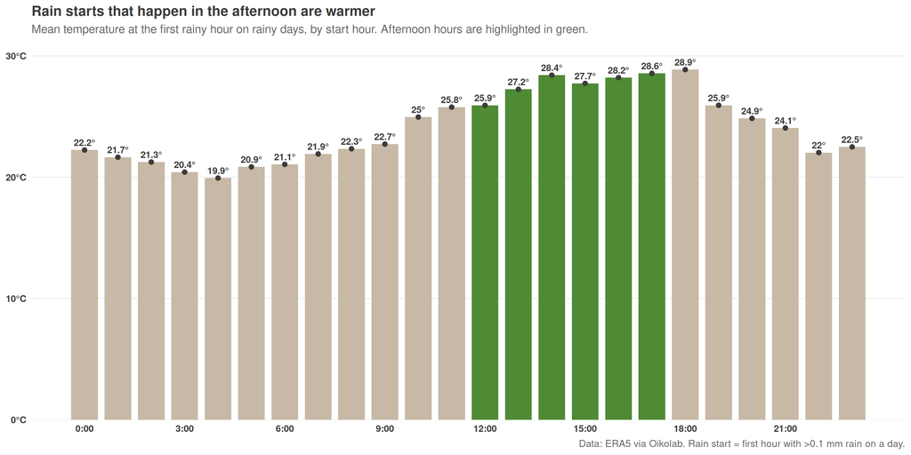

```r
chart_path <- file.path(chart_dir, "rain-start-afternoon-temp.png")

plot_data <- start_hour_summary %>%
  mutate(start_hour_label = factor(start_hour_label, levels = start_hour_label))

p <- ggplot(plot_data, aes(x = start_hour, y = mean_start_temp)) +
  geom_col(aes(fill = afternoon), width = 0.8) +
  geom_point(size = 1.8, color = "#3C3C3C") +
  geom_text(
    aes(label = paste0(round(mean_start_temp, 1), "°")),
    vjust = -0.6,
    size = 3.1,
    fontface = "bold",
    color = "#3C3C3C"
  ) +
  scale_fill_manual(values = c(`TRUE` = "#4F8A35", `FALSE` = "#C7B9A6")) +
  scale_x_continuous(breaks = seq(0, 23, 3), labels = paste0(seq(0, 23, 3), ":00")) +
  scale_y_continuous(labels = label_number(suffix = "°C"), expand = expansion(mult = c(0, 0.08))) +
  labs(
    title = "Rain starts that happen in the afternoon are warmer",
    subtitle = "Mean temperature at the first rainy hour on rainy days, by start hour. Afternoon hours are highlighted in green.",
    caption = "Data: ERA5 via Oikolab. Rain start = first hour with >0.1 mm rain on a day."
  ) +
  theme_weather_question()

p
```

```r
ggsave(chart_path, p, width = 12, height = 6, dpi = 180, bg = "white")
```

## Verdict

Insightful: no

This is a clean descriptive average, but it does not sharpen a strong prior or reveal a surprising pattern. The useful answer is that rainy-day starts in the afternoon average about 27.6°C, with most of those starts landing around mid-to-late afternoon rather than a single sharp hour. That is informative, but not distinctive enough to publish.

Charts:

- `docs/assets/analysis/rain-start-afternoon-temp.png`

Blog post:

- not published
- if this becomes insightful, create `docs/blog/rain-start-afternoon-temp.html`
- include `This post is AI-written.` at the top of the article body
- end with an `Original question` section containing on the days it has rained in Bangalore what has been the average afternoon temperature at the time of the rain starting?
- add the post to the top of `docs/blog/index.html` and `docs/blog/feed.xml`
- add `blog_url: "blog/rain-start-afternoon-temp.html"` to `analysis_questions/analyses.yml`